# Typical Analysis and Testing…CV, Straight 80 missing

## Load the Data

```r
library(tidyverse)
library(HatcheryPedAgree)

genotypes <- read_rds("../private/cvsh_genotypes.rds")
metadata <- read_rds("../private/cvsh_metadata.rds")
```

## Assess Patterns of Missing Data, and deal with it

```r
miss_dsn <- genotypes %>%
  group_by(indiv) %>%
  summarise(
    num_all_loci = n() / 2,  # check to make sure each gene copy is explicitly listed as NA
    num_non_miss_loci = sum(!is.na(allele_int)) / 2)
count(miss_dsn, num_all_loci)  # good.  Everyone has 93 loci (even if some are missing)
```

| num_all_loci | n |
| --- | --- |
| 93 | 23670 |

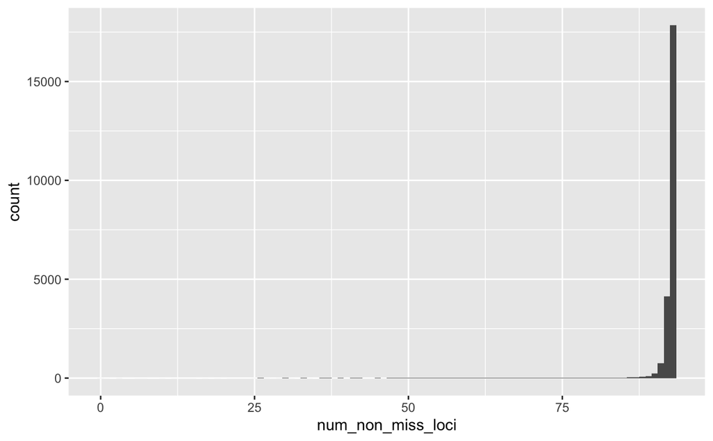

```r
full_histo <- ggplot(miss_dsn, aes(x = num_non_miss_loci)) +
  geom_histogram(binwidth = 1)
full_histo
```

Zoom in on that a bit:

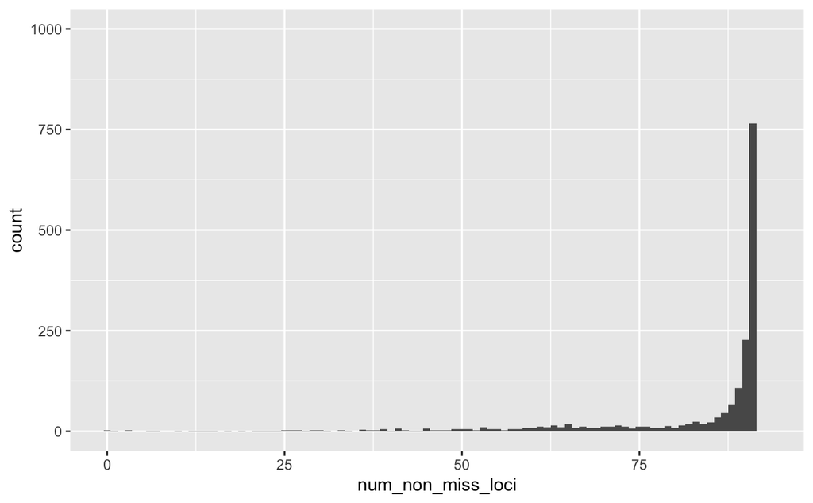

```r
full_histo +
  ylim(0, 1000)
```

How many fish would different cutoffs remove? Let’s see what different choices would give us in terms of how many individuals are retained/removed:

```r
miss_dsn %>%
  count(num_non_miss_loci) %>%
  arrange(desc(num_non_miss_loci)) %>%
  mutate(
    fract_retained = cumsum(n) / sum(n),
    fract_tossed = 1 - fract_retained
    )
```

| num_non_miss_loci | n | fract_retained | fract_tossed |
| --- | --- | --- | --- |
| 93 | 17840 | 0.7536967 | 2.463033e-01 |
| 92 | 4122 | 0.9278411 | 7.215885e-02 |
| 91 | 765 | 0.9601605 | 3.983946e-02 |
| 90 | 227 | 0.9697507 | 3.024926e-02 |
| 89 | 108 | 0.9743135 | 2.568652e-02 |
| 88 | 65 | 0.9770596 | 2.294043e-02 |
| 87 | 46 | 0.9790030 | 2.099704e-02 |
| 86 | 35 | 0.9804816 | 1.951838e-02 |
| 85 | 23 | 0.9814533 | 1.854668e-02 |
| 84 | 18 | 0.9822138 | 1.778623e-02 |

[output cut: 73 more lines]

Let’s set the non-missing locus cutoff to >= 84 loci. That is about 10% missing, and means we toss 1.77% of our samples.

```r
meta <- metadata %>%
  semi_join(miss_dsn %>% filter(num_non_miss_loci >= 84), by = "indiv")
genos <- genotypes %>%
  semi_join(miss_dsn %>% filter(num_non_miss_loci >= 84), by = "indiv")
```

## Matching Samples

```r
# first time through, just get the distribution of matching proportions
for_histo <- find_matching_samples(genos, min_frac_matching = 0.8)
```

```
Summary Statistics:

23249 Individuals in Sample

93 Loci: OMGH1PROM1-SNP1, Omy_AldA, Omy_arp-630, Omy_aspAT-123, Omy_COX1-221, Omy_g12-82, Omy_gh-475, Omy_gsdf-291, Omy_mapK3-103, Omy_mcsf-371, Omy_nramp-146, Omy_Ogo4-304, OMY_PEPA-INT6, ONMYCRBF_1-SNP1, SH100771-63, SH100974-386, SH101554-306, SH101770-410, SH101832-195, SH101993-189, SH102420-63…

1 Reporting Units: dummy_repunit

1 Collections: dummy_collection

0.37% of allelic data identified as missing
```

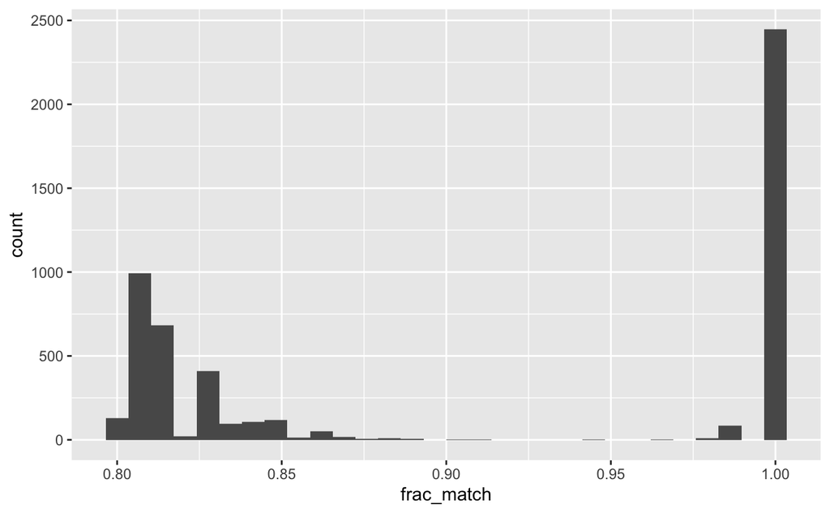

```r
# check the distribution
for_histo$pairs %>%
  mutate(frac_match = num_match / num_non_miss) %>%
  ggplot(aes(x = frac_match)) +
  geom_histogram()
```

```r
# get the clusters of matching genotypes each indvidual belongs to
for_real <- find_matching_samples(genos, min_frac_matching = 0.95, return_clusters = TRUE)
```

```
Summary Statistics:

23249 Individuals in Sample

93 Loci: OMGH1PROM1-SNP1, Omy_AldA, Omy_arp-630, Omy_aspAT-123, Omy_COX1-221, Omy_g12-82, Omy_gh-475, Omy_gsdf-291, Omy_mapK3-103, Omy_mcsf-371, Omy_nramp-146, Omy_Ogo4-304, OMY_PEPA-INT6, ONMYCRBF_1-SNP1, SH100771-63, SH100974-386, SH101554-306, SH101770-410, SH101832-195, SH101993-189, SH102420-63…

1 Reporting Units: dummy_repunit

1 Collections: dummy_collection

0.37% of allelic data identified as missing
```

```r
# we will end up using the identified clusters
head(for_real$clusters)
```

| indiv | cluster |
| --- | --- |
| M049135 | 1 |
| M053329 | 1 |
| M049157 | 2 |
| M053284 | 2 |
| M049193 | 3 |
| M053624 | 3 |

## Reorganizing for SNPPIT

At this point, `for_real$clusters` is the tibble we need to re-organize our genotypes and meta-data for SNPPIT. For every cluster of matching samples we will use, as the genotype, the sample with the least missing data. We will also use the sex of that individual (sometimes there are mismatches in the sex of the matching genotypes). Sometimes there are mismatches in the hatchery of the matching genotypes. In those cases, each separate hatchery gets its own canonical individual named as the ID of the main canonical individual with the hatchery name appended to it. The following function takes care of this and reorganizes both the genotypes and also the meta data into `snppit_genos` and `snppit_meta` (as well as a few other list components).

```r
reorg <- reorganize_matching_samples(
  genotypes = genos,
  metadata = meta,
  clusters = for_real$clusters
)
```

```
Some matching genotypes found in different hatcheries. See cross_hatchery_matches in output.
Some matching genotypes found to have different sexes. See cross_sex_matches in output.
```

Let’s have a look at some of the different components of that output.

### `matchers_metadata`

This is the meta data for all the matching genotypes. Column `original_id` shows what they were named on input, and column `new_id` shows the ID used to identify them now in the SNPPIT-ready output.

```r
reorg$matchers_metadata
```

| cluster | new_id | retained_id | original_id | spawner_group | sex | year | hatchery | NMFS_DNA_ID | BOX_ID | BOX_POSITION | SAMPLE_ID | BATCH_ID | PROJECT_NAME | GENUS | SPECIES | LENGTH | WEIGHT | SEX | AGE | REPORTED_LIFE_STAGE | PHENOTYPE | HATCHERY_MARK | TAG_NUMBER | COLLECTION_DATE | CollectionYear | ESTIMATED_DATE | PICKER | PICK_DATE | LEFTOVER_SAMPLE | … |
| --- | --- | --- | --- | --- | --- | --- | --- | --- | --- | --- | --- | --- | --- | --- | --- | --- | --- | --- | --- | --- | --- | --- | --- | --- | --- | --- | --- | --- | --- | --- |
| 1 | M049135 | M049135 | M049135 | 1/6/11 | Female | 2011 | Coleman_Hatchery | M049135 | M497 | 3D | M110065COL | 3725 | NA | Oncorhynchus | mykiss | 700 | NA | Female | NA | ADULT | NA | AD | NA | 1/6/11 | 2011 | NA | VA | 7/6/11 | NA | … |
| 1 | M049135 | M049135 | M053329 | 1/5/12 | Female | 2012 | Coleman_Hatchery | M053329 | M540 | 11F | M120054COL | 3898 | NA | Oncorhynchus | mykiss | 730 | NA | Female | NA | NA | NA | AD | NA | 1/5/12 | 2012 | NA | DSW | 2/1/12 | NA | … |
| 2 | M049157 | M049157 | M049157 | 1/6/11 | Female | 2011 | Coleman_Hatchery | M049157 | M497 | 6B | M110087COL | 3725 | NA | Oncorhynchus | mykiss | 486 | NA | Female | NA | ADULT | NA | AD | NA | 1/6/11 | 2011 | NA | VA | 7/6/11 | NA | … |
| 2 | M049157 | M049157 | M053284 | 1/5/12 | Female | 2012 | Coleman_Hatchery | M053284 | M540 | 6A | M120009COL | 3898 | NA | Oncorhynchus | mykiss | 576 | NA | Female | NA | NA | NA | AD | NA | 1/5/12 | 2012 | NA | JM | 2/1/12 | NA | … |
| 3 | M049193 | M049193 | M049193 | 1/13/11 | Female | 2011 | Coleman_Hatchery | M049193 | M497 | 10F | M110123COL | 3725 | NA | Oncorhynchus | mykiss | 504 | NA | Female | NA | ADULT | NA | AD | NA | 1/13/11 | 2011 | NA | VA | 7/6/11 | NA | … |
| 3 | M049193 | M049193 | M053624 | 1/26/12 | Female | 2012 | Coleman_Hatchery | M053624 | M543 | 12E | M120349COL | 3898 | NA | Oncorhynchus | mykiss | 520 | NA | Female | NA | NA | NA | AD | NA | 1/26/12 | 2012 | NA | DSW | 4/13/12 | NA | … |
| 4 | M049196 | M049196 | M049196 | 1/13/11 | Female | 2011 | Coleman_Hatchery | M049196 | M497 | 11A | M110126COL | 3725 | NA | Oncorhynchus | mykiss | 497 | NA | Female | NA | ADULT | NA | AD | NA | 1/13/11 | 2011 | NA | VA | 7/6/11 | NA | … |
| 4 | M049196 | M049196 | M053374 | 1/12/12 | Female | 2012 | Coleman_Hatchery | M053374 | M541 | 5C | M120099COL | 3898 | NA | Oncorhynchus | mykiss | 590 | NA | Female | NA | NA | NA | AD | NA | 1/12/12 | 2012 | NA | DSW | 4/12/12 | NA | … |
| 5 | M049222 | M049222 | M049222 | 12/29/10 | Female | 2011 | Coleman_Hatchery | M049222 | M498 | 2C | M100011COL | 3725 | NA | Oncorhynchus | mykiss | 585 | NA | Female | NA | ADULT | NA | AD | NA | 12/29/10 | 2011 | NA | VA | 6/15/11 | NA | … |
| 5 | M049222 | M049222 | M053545 | 1/19/12 | Female | 2012 | Coleman_Hatchery | M053545 | M543 | 2F | M120270COL | 3898 | NA | Oncorhynchus | mykiss | 605 | NA | Female | NA | NA | NA | AD | NA | 1/19/12 | 2012 | NA | DSW | 4/13/12 | NA | … |

[output cut: 990 more lines]

### `snppit_meta` and `snppit_genos`

These are the tibbles that are ready to pass into `prepare_snppit_infile()`. Multiple years and spawner_groups of the matching individuals have been lumped into comma-separated strings for the year and spawner group inputs to SNPPIT.

### `cross_hatchery_matches`

A tibble that shows you which clusters of matching genotypes included fish from more than one hatchery.

```r
reorg$cross_hatchery_matches
```

| cluster | retained_id | original_id | spawner_group | sex | year | hatchery | NMFS_DNA_ID | BOX_ID | BOX_POSITION | SAMPLE_ID | BATCH_ID | PROJECT_NAME | GENUS | SPECIES | LENGTH | WEIGHT | SEX | AGE | REPORTED_LIFE_STAGE | PHENOTYPE | HATCHERY_MARK | TAG_NUMBER | COLLECTION_DATE | CollectionYear | ESTIMATED_DATE | PICKER | PICK_DATE | LEFTOVER_SAMPLE | SAMPLE_COMMENTS | … |
| --- | --- | --- | --- | --- | --- | --- | --- | --- | --- | --- | --- | --- | --- | --- | --- | --- | --- | --- | --- | --- | --- | --- | --- | --- | --- | --- | --- | --- | --- | --- |
| 208 | M053148 | M053148 | 1/4/11 | Female | 2011 | Nimbus_Hatchery | M053148 | M539 | 1A | M110001NIM | 3725 | NA | Oncorhynchus | mykiss | 726 | NA | Female | NA | NA | NA | AD | NA | 1/4/11 | 2011 | NA | DSW | 2/1/12 | NA | Re-sent from right hatchery. | … |
| 208 | M053148 | M053323 | 1/5/12 | Female | 2012 | Coleman_Hatchery | M053323 | M540 | 10H | M120048COL | 3898 | NA | Oncorhynchus | mykiss | 515 | NA | Female | NA | NA | NA | AD | NA | 1/5/12 | 2012 | NA | DSW | 2/1/12 | NA | NA | … |
| 210 | M053196 | M053196 | 1/11/11 | Male | 2011 | Nimbus_Hatchery | M053196 | M539 | 7A | M110049NIM | 3725 | NA | Oncorhynchus | mykiss | 715 | NA | Male | NA | NA | NA | AD | NA | 1/11/11 | 2011 | NA | DSW | 2/1/12 | NA | Re-sent from right hatchery. | … |
| 210 | M053196 | M053331 | 1/5/12 | Male | 2012 | Coleman_Hatchery | M053331 | M540 | 11H | M120056COL | 3898 | NA | Oncorhynchus | mykiss | 500 | NA | Male | NA | NA | NA | AD | NA | 1/5/12 | 2012 | NA | DSW | 2/1/12 | NA | NA | … |
| 211 | M053244 | M053244 | 1/11/11 | Male | 2011 | Nimbus_Hatchery | M053244 | M540 | 1A | M110098NIM | 3725 | NA | Oncorhynchus | mykiss | 695 | NA | Male | NA | NA | NA | AD | NA | 1/11/11 | 2011 | NA | DSW | 2/1/12 | NA | Re-sent from right hatchery. | … |
| 211 | M053244 | M053339 | 1/12/12 | Male | 2012 | Coleman_Hatchery | M053339 | M540 | 12H | M120064COL | 3898 | NA | Oncorhynchus | mykiss | 430 | NA | Male | NA | NA | NA | AD | NA | 1/12/12 | 2012 | NA | DSW | 2/1/12 | NA | NA | … |
| 1495 | M098336 | M098336 | ? | Male | 2017 | Feather_River_Hatchery | M098336 | M1001 | 11E | M170376FRH | 4901 | NA | Oncorhynchus | mykiss | 417 | NA | Male | NA | ADULT | NA | AD | NA | NA | 2017 | NA | LC | 1/25/17 | None | INCOMING TUB #10; CAUDAL TAG BLACK #2Spawned with M170360FRH & M170361FRH | … |
| 1495 | M098336 | M098834 | 1/31/17 | Male | 2017 | Nimbus_Hatchery | M098834 | M1007 | 1G | M170292NIM | 4902 | NA | Oncorhynchus | mykiss | 405 | NA | Male | NA | ADULT | NA | AD | NA | 1/31/17 | 2017 | NA | LC | 2/8/17 | NA | NA | … |
| 1666 | M104514 | M104514 | 1/17/18 | Male | 2018 | Feather_River_Hatchery | M104514 | M1066 | 3G | M180655FRH | 5070 | NA | Oncorhynchus | mykiss | 502 | NA | Male | NA | ADULT | NA | AD | NA | 1/17/18 | 2018 | NA | LC | 3/2/18 | NA | Spawned with M180677FRH & M180678FRH | … |
| 1666 | M104514 | M107170 | 2/7/18 | Male | 2018 | Coleman_Hatchery | M107170 | M1093 | 11G | M180789COL | 5120 | NA | Oncorhynchus | mykiss | 500 | NA | Male | NA | ADULT | NA | AD | NA | 2/7/18 | 2018 | NA | LC | 5/11/18 | None | NA | … |

### `cross_sex_matches`

A tibble that shows you which clusters of matching genotypes included fish with more than one reported sex

```r
reorg$cross_sex_matches
```

| cluster | retained_id | original_id | spawner_group | sex | year | hatchery | NMFS_DNA_ID | BOX_ID | BOX_POSITION | SAMPLE_ID | BATCH_ID | PROJECT_NAME | GENUS | SPECIES | LENGTH | WEIGHT | SEX | AGE | REPORTED_LIFE_STAGE | PHENOTYPE | HATCHERY_MARK | TAG_NUMBER | COLLECTION_DATE | CollectionYear | ESTIMATED_DATE | PICKER | PICK_DATE | LEFTOVER_SAMPLE | SAMPLE_COMMENTS | … |
| --- | --- | --- | --- | --- | --- | --- | --- | --- | --- | --- | --- | --- | --- | --- | --- | --- | --- | --- | --- | --- | --- | --- | --- | --- | --- | --- | --- | --- | --- | --- |
| 72 | M050192 | M050192 | 12/29/10 | Female | 2011 | Feather_River_Hatchery | M050192 | M508 | 3E | M100127FRH | 3725 | NA | Oncorhynchus | mykiss | 467 | NA | Female | NA | ADULT | NA | AD | NA | 12/29/10 | 2011 | NA | CC | 7/12/11 | NA | NA | … |
| 72 | M050192 | M050295 | 1/5/11 | Male | 2011 | Feather_River_Hatchery | M050295 | M509 | 4D | M110063FRH | 3725 | NA | Oncorhynchus | mykiss | 468 | NA | Male | NA | ADULT | NA | AD | NA | 1/5/11 | 2011 | NA | VA | 7/12/11 | NA | SCALE ID: FRH010511SH31 | … |
| 159 | M050822 | M050822 | 1/13/11 | Female | 2011 | Mokelumne_River_Hatchery | M050822 | M514 | 10C | M110045MKH | 3725 | NA | Oncorhynchus | mykiss | 446 | NA | Female | NA | ADULT | NA | AD | NA | 1/13/11 | 2011 | NA | CC | 7/15/11 | NA | NA | … |
| 159 | M050822 | M055235 | 12/22/11 | Male | 2012 | Mokelumne_River_Hatchery | M055235 | M560 | 9H | M110198MKH | 3898 | NA | Oncorhynchus | mykiss | 551 | NA | Male | NA | NA | NA | AD | NA | 12/22/11 | 2012 | NA | DSW | 5/10/12 | NA | NA | … |
| 201 | M051340 | M051340 | 2/8/11 | Female | 2011 | Nimbus_Hatchery | M051340 | M520 | 3A | M110276NIM | 3725 | NA | Oncorhynchus | mykiss | 690 | NA | Female | NA | ADULT | NA | AD | NA | 2/8/11 | 2011 | NA | CC | 7/18/11 | NA | NA | … |
| 201 | M051340 | M051341 | 2/8/11 | Male | 2011 | Nimbus_Hatchery | M051341 | M520 | 3B | M110277NIM | 3725 | NA | Oncorhynchus | mykiss | 738 | NA | Male | NA | ADULT | NA | AD | NA | 2/8/11 | 2011 | NA | CC | 7/18/11 | NA | NA | … |
| 241 | M054209 | M054209 | 1/6/12 | NA | 2012 | Feather_River_Hatchery | M054209 | M550 | 1F | M120082FRH | 3898 | NA | Oncorhynchus | mykiss | 522 | NA | NA | NA | NA | NA | AD | NA | 1/6/12 | 2012 | NA | DSW | 4/24/12 | NA | NA | … |
| 241 | M054209 | M054400 | 1/13/12 | Male | 2012 | Feather_River_Hatchery | M054400 | M552 | 1E | M120273FRH | 3898 | NA | Oncorhynchus | mykiss | 525 | NA | Male | NA | NA | NA | AD | NA | 1/13/12 | 2012 | NA | JM | 4/24/12 | NA | NA | … |
| 283 | M054356 | M054356 | 1/13/12 | Female | 2012 | Feather_River_Hatchery | M054356 | M551 | 8A | M120229FRH | 3898 | NA | Oncorhynchus | mykiss | 470 | NA | Female | NA | NA | NA | AD | NA | 1/13/12 | 2012 | NA | JM | 4/24/12 | NA | NA | … |
| 283 | M054356 | M061759 | 1/9/13 | Female | 2013 | Feather_River_Hatchery | M061759 | M629 | 9C | M130251FRH | 4102 | NA | Oncorhynchus | mykiss | 508 | NA | Female | NA | ADULT | NA | AD | NA | 1/9/13 | 2013 | NA | VA | 4/4/13 | NA | NA | … |

[output cut: 188 more lines]

## Prepare a SNPPIT infile and run it

We have rolled these two steps into a single run_snppit() function.

Internally, it calls `prepare_snppit_infile()` to write the data, and then it runs `snppit` inside the `system()` command.

Here is what that looks like:

```r
snppit_dir1 <- run_snppit(reorg$snppit_genos, reorg$snppit_meta)
```

```
Preparing SNPPIT data into file /var/folders/2j/5gr70s2x3yncdfcp6pcfybfh0000gn/T//RtmpPjGkcX/file2046399fd0d5/snppit_input.txt
snppit input file written to /var/folders/2j/5gr70s2x3yncdfcp6pcfybfh0000gn/T//RtmpPjGkcX/file2046399fd0d5/snppit_input.txt
Running snppit in directory /var/folders/2j/5gr70s2x3yncdfcp6pcfybfh0000gn/T//RtmpPjGkcX/file2046399fd0d5
```

[output not shown]

[output cut: 786 more lines]

```
PRINTING FINAL PARENTAGE REPORT


SNPPIT PROGRAM EXECUTION COMPLETED.

Output is in the following files:
    snppit_output_ParentageAssignments.txt -- Main output file that gives false discovery rates for all offspring with the most likely parents
    snppit_output_BasicDataSummary.txt -- Basic information about the data that got read in.
    snppit_output_ChosenSMAXes.txt -- Information about the smax vectors used in the analysis.
    snppit_output_FDR_Summary.txt -- Offspring assigned to parents in each population, ranked by false discovery rate.
    snppit_output_PopSizesAnPiVectors.txt -- Information about the sizes of the populations and the expected fraction of different trios thereby implied.
    snppit_output_TrioPosteriors.txt -- Posterior probs for all non-excluded parent pairs of every offspring in the data file.


Questions, etc.? Send them to eric.anderson@noaa.gov
```

```r
snppit_dir1
```

```
[1] "/var/folders/2j/5gr70s2x3yncdfcp6pcfybfh0000gn/T//RtmpPjGkcX/file2046399fd0d5"
```

# Running Time

Running the code and rendering this notebook required approximately this much time on a Mac laptop of middling speed:

```r
Sys.time() - start_time
```

[output not shown]

## Slurp up the results

```r
# here we call the "constrained" runs SAD for "sex_and_date"
SAD_results <- slurp_snppit(snppit_dir1, reorg$snppit_meta)
dir.create("outputs")
write_rds(SAD_results, path = "outputs/CV_SAD_results.rds", compress = "xz")
```

## Then do an unconstrained or “noSAD” run

```r
snppit_dir_noSAD <- run_snppit(
  reorg$snppit_genos,
  reorg$snppit_meta,
  outdir = "../tmp_snppit_arena/CV_no_SAD_run",
  use_spawner_group = FALSE,
  use_sex = FALSE
  )
no_SAD_results <- slurp_snppit("../tmp_snppit_arena/CV_no_SAD_run", reorg$snppit_meta)
write_rds(no_SAD_results, path = "outputs/CV_no_SAD_results.rds", compress = "xz")
```